# RMarkdown Assignment

## Content

Our [group project](http://sbfire.weebly.com/) is an *assessment* of the benefits of fire mitigation programs cities in the **wildland urban interface**, using Santa Barbara as a case study. We have already distributed a survey to the residents of the City of Santa Barbara’s Wildland Fire Suppression Assessment District in order to gauge the attitudes of the residents toward the program. We have also ran fire modeling programs to determine the effectiveness of the vegetation treatments of the program. The final component of our project will be looking at the transferability of the program, and we are trying to determine what other cities in California may benefit from a similar program.

The picture below shows the extent of the Wildland Fire Suppression Assessment District in the City of Santa Barbara.

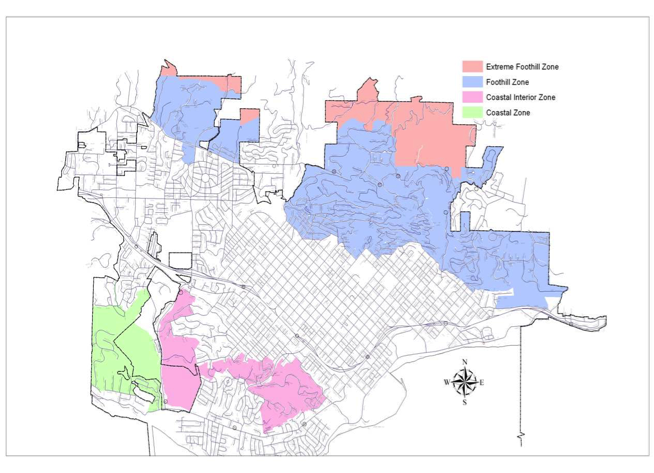

## Techniques

We plan on using AHP to determine the weights that should be given to the variables we have deemed as most important for the transferability of this program. My group chose 5 variables of interest, and we will be giving fire experts the AHP survey to give us their opinion on their relative importances. Learning to be more fluent with writing code for models will help us turn the AHP information into a GIS model that picks cities with similar traits to Santa Barbara. I look forward to learning how to make an interactive map that can clearly and concisely explain our findings.

- Variables of Interest
  - Fire Frequency
  - WUI Index
  - Vegetation Type
  - Topography
  - Demographics

## Data

We have found GIS data layers and historic fire data from CalFire for the 5 variables of interest with which we will create the model to narrow down to the cities that could benefit from a similar program.

```r
# read csv
d = read.csv('./data/julimatos_FullData.csv')

# output summary
summary(d)
```

```
##      years          fireRisk           vote         districtBen
##  Min.   : 0.20   Min.   : 1.000   Min.   : 0.000   Min.   : 1.000
##  1st Qu.:10.00   1st Qu.: 3.000   1st Qu.: 1.000   1st Qu.: 4.000
##  Median :18.00   Median : 4.000   Median : 1.000   Median : 4.000
##  Mean   :22.63   Mean   : 6.342   Mean   : 4.071   Mean   : 7.222
##  3rd Qu.:33.00   3rd Qu.: 5.000   3rd Qu.: 2.000   3rd Qu.: 5.000
##  Max.   :74.80   Max.   :69.000   Max.   :69.000   Max.   :69.000
##   districtSuc      districtSafe        forest            evac
##  Min.   : 1.000   Min.   : 1.000   Min.   : 1.000   Min.   : 0.000
##  1st Qu.: 3.000   1st Qu.: 3.000   1st Qu.: 3.000   1st Qu.: 1.000
##  Median : 4.000   Median : 4.000   Median : 4.000   Median : 1.000
##  Mean   : 7.145   Mean   : 7.191   Mean   : 7.417   Mean   : 2.545
##  3rd Qu.: 5.000   3rd Qu.: 5.000   3rd Qu.: 5.000   3rd Qu.: 1.000
##  Max.   :69.000   Max.   :69.000   Max.   :69.000   Max.   :69.000
##       chip            noChip         defense         noDefense
##  Min.   : 0.000   Min.   : 0.00   Min.   : 0.000   Min.   : 0.00
##  1st Qu.: 0.000   1st Qu.: 4.00   1st Qu.: 0.000   1st Qu.: 3.00
##  Median : 1.000   Median :69.00   Median : 0.000   Median : 5.00
##  Mean   : 2.908   Mean   :41.88   Mean   : 2.969   Mean   :34.47
##  3rd Qu.: 2.000   3rd Qu.:69.00   3rd Qu.: 1.000   3rd Qu.:69.00
##  Max.   :69.000   Max.   :69.00   Max.   :69.000   Max.   :69.00
##     lostHome         ownRent            income           eth
##  Min.   : 0.000   Min.   : 0.0000   Min.   : 1.00   Min.   : 1.00
##  1st Qu.: 0.000   1st Qu.: 0.0000   1st Qu.: 2.00   1st Qu.: 1.00
##  Median : 0.000   Median : 0.0000   Median : 3.00   Median : 1.00
##  Mean   : 2.176   Mean   : 0.3459   Mean   :25.62   Mean   :18.54
##  3rd Qu.: 0.000   3rd Qu.: 0.0000   3rd Qu.:69.00   3rd Qu.:69.00
##  Max.   :69.000   Max.   :69.0000   Max.   :69.00   Max.   :69.00
##    spouseEth          edu
##  Min.   : 1.00   Min.   : 2.00
##  1st Qu.: 1.00   1st Qu.: 3.00
##  Median : 1.00   Median : 4.00
##  Mean   :31.92   Mean   :19.58
##  3rd Qu.:69.00   3rd Qu.: 4.00
##  Max.   :69.00   Max.   :69.00
```

[My Organization](http://fire-mitigation.github.io/)

## Data Wrangling

```r
# present working directory
getwd()
```

```
## [1] "/Users/julianamatos/Documents/Bren/ESM296INF/env-info/students"
```

```r
# change working directory
setwd('.')

# list files
list.files()
```

```
##  [1] "adam1993.html"         "adam1993.Rmd"
##  [3] "alxsmith.html"         "alxsmith.Rmd"
##  [5] "bbest.html"            "bbest.Rmd"
##  [7] "caio-faro.html"        "caio-faro.Rmd"
##  [9] "daalbu.Rmd"            "data"
## [11] "gmcdonald-sfg.html"    "gmcdonald-sfg.Rmd"
## [13] "images"                "index.md"
## [15] "jcvdav.html"           "jcvdav.Rmd"
## [17] "jebone.html"           "jebone.Rmd"
## [19] "jepa.html"             "jepa.Rmd"
## [21] "jkidson.html"          "jkidson.Rmd"
## [23] "juanmayorgahenao.html" "juanmayorgahenao.Rmd"
## [25] "julianaherrera.html"   "julianaherrera.Rmd"
## [27] "julimatos.html"        "julimatos.Rmd"
## [29] "jupa1089.html"         "jupa1089.Rmd"
## [31] "knboysen.html"         "knboysen.Rmd"
## [33] "maierucsb.html"        "maierucsb.Rmd"
## [35] "pricessnapper.csv"     "sgriff.html"
## [37] "sgriff.Rmd"            "smccutcheon.html"
## [39] "smccutcheon.Rmd"       "snappermap.png"
## [41] "sparrow925.html"       "sparrow925.Rmd"
## [43] "wag7.html"             "wag7.Rmd"
```

```r
# list files that end in '.jpg'
list.files(pattern=glob2rx('*.jpg'))
```

```
## character(0)
```

```r
# file exists
file.exists('test.png')
```

```
## [1] FALSE
```

## Read a CSV

```r
d = read.csv('../data/r-ecology/species.csv')
d
```

```
##    species_id            genus         species    taxa
## 1          AB       Amphispiza       bilineata    Bird
## 2          AH Ammospermophilus         harrisi  Rodent
## 3          AS       Ammodramus      savannarum    Bird
## 4          BA          Baiomys         taylori  Rodent
## 5          CB  Campylorhynchus brunneicapillus    Bird
## 6          CM      Calamospiza     melanocorys    Bird
## 7          CQ       Callipepla        squamata    Bird
## 8          CS         Crotalus      scutalatus Reptile
## 9          CT    Cnemidophorus          tigris Reptile
## 10         CU    Cnemidophorus       uniparens Reptile
## 11         CV         Crotalus         viridis Reptile
## 12         DM        Dipodomys        merriami  Rodent
## 13         DO        Dipodomys           ordii  Rodent
## 14         DS        Dipodomys     spectabilis  Rodent
```

[output cut: 40 more lines]

```r
head(d)
```

```
##   species_id            genus         species   taxa
## 1         AB       Amphispiza       bilineata   Bird
## 2         AH Ammospermophilus         harrisi Rodent
## 3         AS       Ammodramus      savannarum   Bird
## 4         BA          Baiomys         taylori Rodent
## 5         CB  Campylorhynchus brunneicapillus   Bird
## 6         CM      Calamospiza     melanocorys   Bird
```

```r
summary(d)
```

```
##    species_id             genus         species        taxa
##  AB     : 1   Chaetodipus    : 4   sp.      :10   Bird   :13
##  AH     : 1   Dipodomys      : 4   hispidus : 2   Rabbit : 1
##  AS     : 1   Reithrodontomys: 4   albigula : 1   Reptile: 9
##  BA     : 1   Sigmodon       : 4   audubonii: 1   Rodent :31
##  CB     : 1   Onychomys      : 3   baileyi  : 1
##  CM     : 1   Peromyscus     : 3   bilineata: 1
##  (Other):48   (Other)        :32   (Other)  :38
```

## Read a CSV a better way

```r
library(readr)

d = read_csv('../data/r-ecology/species.csv')
d
```

```
##    species_id            genus         species    taxa
## 1          AB       Amphispiza       bilineata    Bird
## 2          AH Ammospermophilus         harrisi  Rodent
## 3          AS       Ammodramus      savannarum    Bird
## 4          BA          Baiomys         taylori  Rodent
## 5          CB  Campylorhynchus brunneicapillus    Bird
## 6          CM      Calamospiza     melanocorys    Bird
## 7          CQ       Callipepla        squamata    Bird
## 8          CS         Crotalus      scutalatus Reptile
## 9          CT    Cnemidophorus          tigris Reptile
## 10         CU    Cnemidophorus       uniparens Reptile
## 11         CV         Crotalus         viridis Reptile
## 12         DM        Dipodomys        merriami  Rodent
## 13         DO        Dipodomys           ordii  Rodent
## 14         DS        Dipodomys     spectabilis  Rodent
```

[output cut: 40 more lines]

```r
head(d)
```

```
##   species_id            genus         species   taxa
## 1         AB       Amphispiza       bilineata   Bird
## 2         AH Ammospermophilus         harrisi Rodent
## 3         AS       Ammodramus      savannarum   Bird
## 4         BA          Baiomys         taylori Rodent
## 5         CB  Campylorhynchus brunneicapillus   Bird
## 6         CM      Calamospiza     melanocorys   Bird
```

```r
summary(d)
```

```
##   species_id           genus             species
##  Length:54          Length:54          Length:54
##  Class :character   Class :character   Class :character
##  Mode  :character   Mode  :character   Mode  :character
##      taxa
##  Length:54
##  Class :character
##  Mode  :character
```

### Multiple Variables

```r
# read in csv
surveys = read.csv('../data/r-ecology/surveys.csv')

# view data
head(surveys)
```

```
##   record_id month day year plot_id species_id sex hindfoot_length weight
## 1         1     7  16 1977       2         NL   M              32     NA
## 2         2     7  16 1977       3         NL   M              33     NA
## 3         3     7  16 1977       2         DM   F              37     NA
## 4         4     7  16 1977       7         DM   M              36     NA
## 5         5     7  16 1977       3         DM   M              35     NA
## 6         6     7  16 1977       1         PF   M              14     NA
```

```r
summary(surveys)
```

```
##    record_id         month             day             year
##  Min.   :    1   Min.   : 1.000   Min.   : 1.00   Min.   :1977
##  1st Qu.: 8888   1st Qu.: 4.000   1st Qu.: 9.00   1st Qu.:1984
##  Median :17775   Median : 6.000   Median :16.00   Median :1990
##  Mean   :17775   Mean   : 6.474   Mean   :16.11   Mean   :1990
##  3rd Qu.:26662   3rd Qu.: 9.000   3rd Qu.:23.00   3rd Qu.:1997
##  Max.   :35549   Max.   :12.000   Max.   :31.00   Max.   :2002
##
##     plot_id       species_id    sex       hindfoot_length     weight
##  Min.   : 1.0   DM     :10596    : 2506   Min.   : 2.00   Min.   :  4.00
##  1st Qu.: 5.0   PP     : 3123   F:15690   1st Qu.:21.00   1st Qu.: 20.00
##  Median :11.0   DO     : 3027   M:17348   Median :32.00   Median : 37.00
##  Mean   :11.4   PB     : 2891   P:    1   Mean   :29.29   Mean   : 42.67
##  3rd Qu.:17.0   RM     : 2609   R:    3   3rd Qu.:36.00   3rd Qu.: 48.00
##  Max.   :24.0   DS     : 2504   Z:    1   Max.   :70.00   Max.   :280.00
##                 (Other):10799             NA's   :4111    NA's   :3266
```

```r
# limit columns to species and year
surveys_2 = surveys[,c('species_id', 'year')]

# limit rows to just species "NL"
surveys_3 = surveys_2[surveys_2$species_id  == 'NL',]

# get count per year
surveys_4 = aggregate(species_id ~ year, data=surveys_3, FUN='length')

# write to csv
write.csv(surveys_4, 'data/surveys_bbest.csv', row.names = FALSE)
```

### Nested Functions

```r
# read in data
surveys = read.csv('../data/r-ecology/surveys.csv')

# view data
head(surveys)
```

```
##   record_id month day year plot_id species_id sex hindfoot_length weight
## 1         1     7  16 1977       2         NL   M              32     NA
## 2         2     7  16 1977       3         NL   M              33     NA
## 3         3     7  16 1977       2         DM   F              37     NA
## 4         4     7  16 1977       7         DM   M              36     NA
## 5         5     7  16 1977       3         DM   M              35     NA
## 6         6     7  16 1977       1         PF   M              14     NA
```

```r
summary(surveys)
```

```
##    record_id         month             day             year
##  Min.   :    1   Min.   : 1.000   Min.   : 1.00   Min.   :1977
##  1st Qu.: 8888   1st Qu.: 4.000   1st Qu.: 9.00   1st Qu.:1984
##  Median :17775   Median : 6.000   Median :16.00   Median :1990
##  Mean   :17775   Mean   : 6.474   Mean   :16.11   Mean   :1990
##  3rd Qu.:26662   3rd Qu.: 9.000   3rd Qu.:23.00   3rd Qu.:1997
##  Max.   :35549   Max.   :12.000   Max.   :31.00   Max.   :2002
##
##     plot_id       species_id    sex       hindfoot_length     weight
##  Min.   : 1.0   DM     :10596    : 2506   Min.   : 2.00   Min.   :  4.00
##  1st Qu.: 5.0   PP     : 3123   F:15690   1st Qu.:21.00   1st Qu.: 20.00
##  Median :11.0   DO     : 3027   M:17348   Median :32.00   Median : 37.00
##  Mean   :11.4   PB     : 2891   P:    1   Mean   :29.29   Mean   : 42.67
##  3rd Qu.:17.0   RM     : 2609   R:    3   3rd Qu.:36.00   3rd Qu.: 48.00
##  Max.   :24.0   DS     : 2504   Z:    1   Max.   :70.00   Max.   :280.00
##                 (Other):10799             NA's   :4111    NA's   :3266
```

```r
# limit data with [], aggregate to count, write to csv
write.csv(
  aggregate(
    species_id ~ year,
    data = surveys[surveys_2$species_id  == 'NL', c('species_id', 'year')],
    FUN = 'length'),
  'data/surveys_bbest.csv',
  row.names = FALSE)
```

### Elegance with dplyr

```r
# load libraries
library(readr)
library(dplyr)
# read in csv
surveys = read_csv('../data/r-ecology/surveys.csv')

# dplyr elegance
surveys %T>%                          # note tee operator %T>% for glimpse
  glimpse() %>%                       # view data
  select(species_id, year) %>%        # limit columns
  filter(species_id  == 'NL') %>%     # limit rows
  group_by(year) %>%                  # get count by first grouping
  summarize(n = n()) %>%              #   then summarize
  write_csv('data/surveys_bbest.csv') # write out csv
```

```
## Observations: 35,549
## Variables: 9
## $ record_id       (int) 1, 2, 3, 4, 5, 6, 7, 8, 9, 10, 11, 12, 13, 14,...
## $ month           (int) 7, 7, 7, 7, 7, 7, 7, 7, 7, 7, 7, 7, 7, 7, 7, 7...
## $ day             (int) 16, 16, 16, 16, 16, 16, 16, 16, 16, 16, 16, 16...
## $ year            (int) 1977, 1977, 1977, 1977, 1977, 1977, 1977, 1977...
## $ plot_id         (int) 2, 3, 2, 7, 3, 1, 2, 1, 1, 6, 5, 7, 3, 8, 6, 4...
## $ species_id      (chr) "NL", "NL", "DM", "DM", "DM", "PF", "PE", "DM"...
## $ sex             (chr) "M", "M", "F", "M", "M", "M", "F", "M", "F", "...
## $ hindfoot_length (int) 32, 33, 37, 36, 35, 14, NA, 37, 34, 20, 53, 38...
## $ weight          (int) NA, NA, NA, NA, NA, NA, NA, NA, NA, NA, NA, NA...
```